# MA334-Assignment

Data Analysis on the Biodiversity Measures

Reg no: 2211543

### Introduction

**Biodiversity**, the variety of life on Earth, is an essential part of our planet’s ecosystem. It is a measure of variability of species, genetics and the level of ecosystem. In recent times, the biodiversity has been degraded to its lowest extent as a result of recent environmental changes which led to mass extinctions. We have been provided with the data of biodiversity measures of *different taxonomic groups* in various dominant land class and time periods. The data here are based on the 11 taxonomic groups and I’ll be performing analysis on selective 7 taxonomic groups which will be referred as BD7 with BD11. It does contains data in two different time periods such as Y70(from 1970) and Y00(from 2000). The data varies with location in all over Britain which has been segmented by grid squares measuring 100km across and also with different dominant land class accordingly. The segments are based on the *UK National Grid* in which the vertical lines are called Eastings and the horizontal lines are Northings. Their values tend to increase if you travel across east and north respectively. The mean of all taxonomic group has also provided, called **ecologicalStatus**.

I’ll be analyzing the data on biodiversity measure of the selected 7 taxonomic groups i.e, Bees, Bryophytes, Butterflies, Carabids, Hover flies, Grasshoppers Crickets, Vascular plants with all other taxonomic groups in different time periods and in various location. I’ll also be performing some statistics on the data to provide insights into patterns and trends in biodiversity.

##### *Main objectives:*

1. Hypothesis Test
2. Simple Linear Regression
3. Multiple Linear Regression
4. Open analysis on the data

### Data Exploration

The data consists of biodiversity measures for all taxonomic groups over two different time periods and across multiple locations. The *ecologicalStatus* is the mean of all the taxonomic groups’ biodiversity measures and the *Northing*, *Easting* values are the coordinates used to accurately locate them on the map. The *dominantLandClass* is the names of the 45 different land classes in and around the UK. The following plot provides insights on the number of species in every dominantLandClass. The maximum number of species are from **3e** followed by **2e**, where the least are from *18w*.

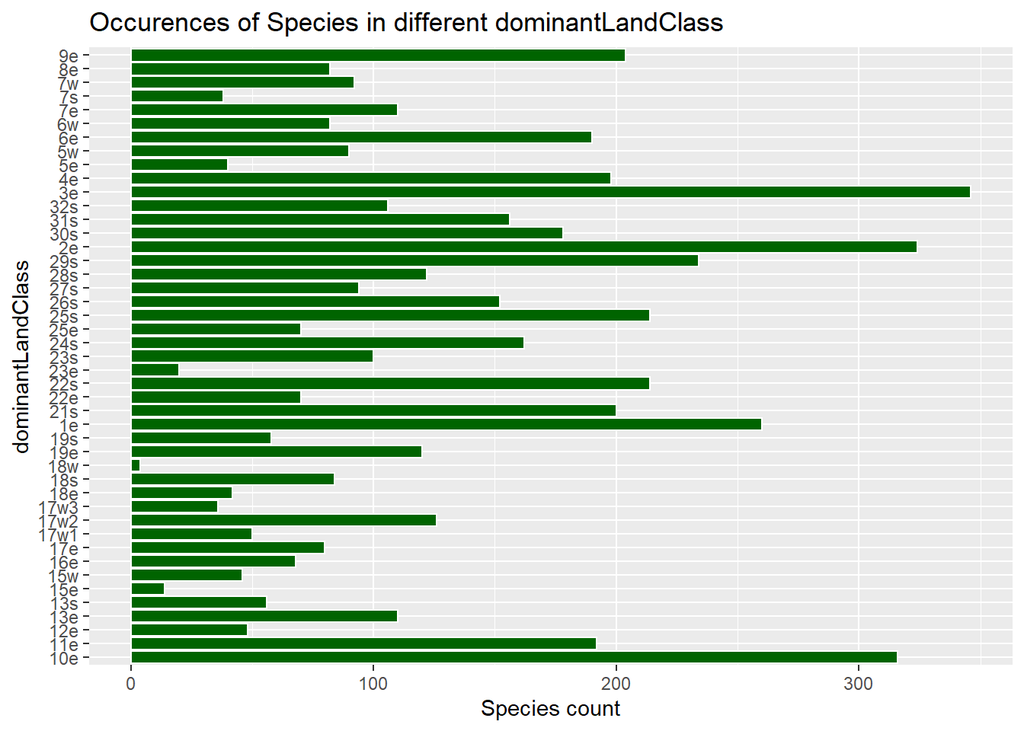

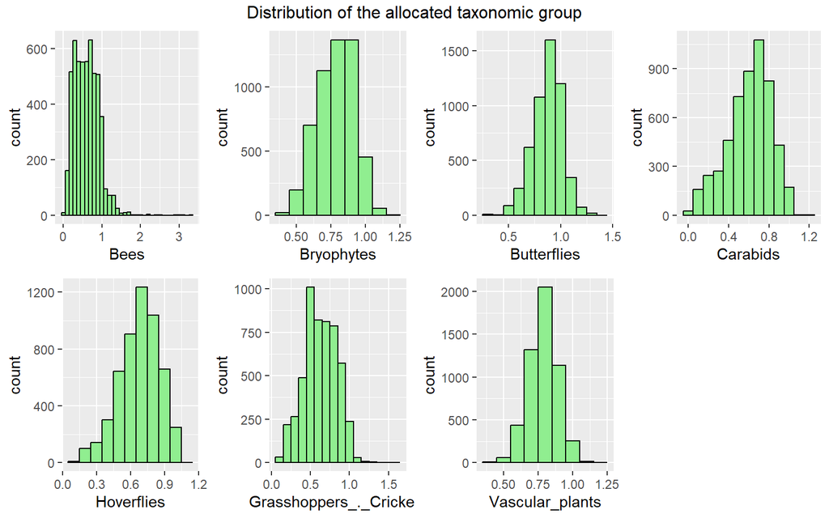

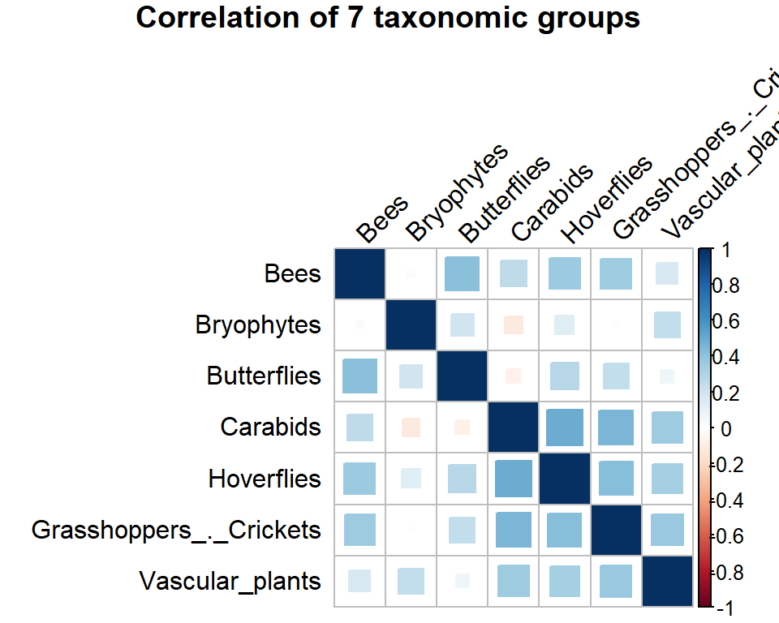

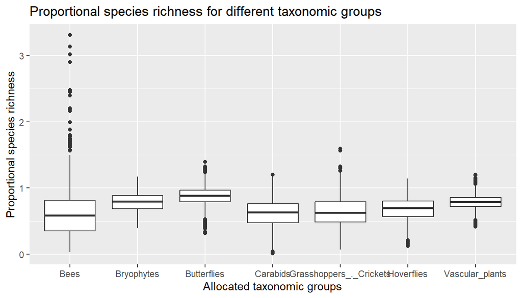

### Hypothesis Testing

The following plot allow a visual comparison of *eco_status_7* over the two periods as well as the distribution of the change in *eco_status_7* in the two periods. The maximum number of outliers in the mean of the seven taxonomic group in the period **Y00** is significantly more than compared to the period **Y70**.

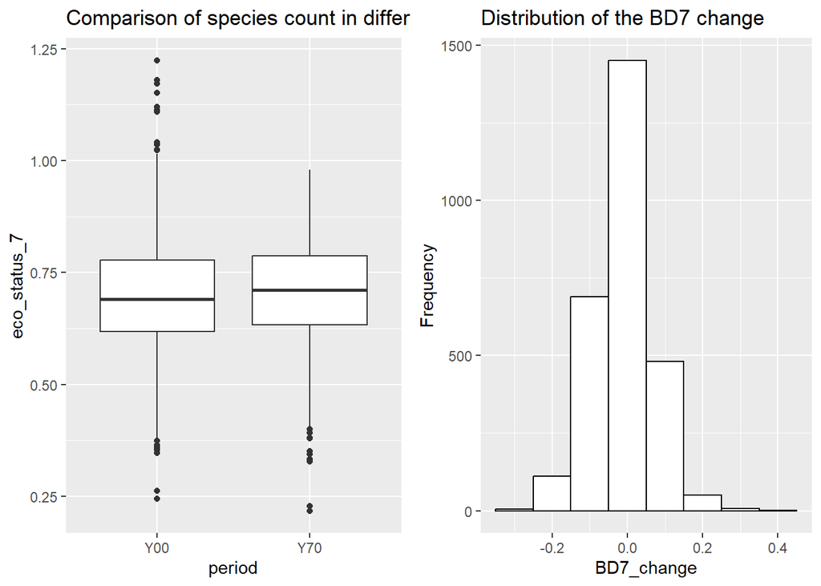

Performing a t.test with the *BD7_change*, which is nothing but the difference (Y00-Y70) of BD7 in two different time period. The frequency of BD7_change is equally distributed, which can be interpreted from the histogram. The null hypothesis of this test is that the population mean of the *BD7_change* is equal to 0. The alternate hypothesis is not equal to 0. The t-test here is used to check whether there is any difference between the mean of the *BD7_change* and the value 0. The t value, -8.2496 denotes that the no.of.standard errors in the sample mean is away from the hypothesized population mean. The df is 2798, and the p-value is 2.417e-16, which is less than the significance level. So the test suggests and supports the alternative hypothesis, as we have stronger evidence against the null hypothesis, which is that the mean of *BD7_change* is different from 0. The mean value lies somewhere between the 95 percent confidence interval, i.e., -0.01213813.

```
    One Sample t-test

data:  BD7_change
t = -8.2496, df = 2798, p-value = 2.417e-16
alternative hypothesis: true mean is not equal to 0
95 percent confidence interval:
 -0.015023199 -0.009253065
sample estimates:
  mean of x
-0.01213813
```

Providing with the plot of Empirical Cumulative distribution function (ecdf) between BD7 data and the BD11 data, which is the overall biodiversity measures of the taxonomic groups. Here the CDF, shows the probability that a random observation from the distribution is less than or equal to a given value, in which the green line represents the 7 taxonomic groups’ mean and the red line denotes the overall mean. From the p-value *3.199e-08* observed from the Kolmogorov-Smirnov test, we can reject the null hypothesis and confirm that there are two different distributions.

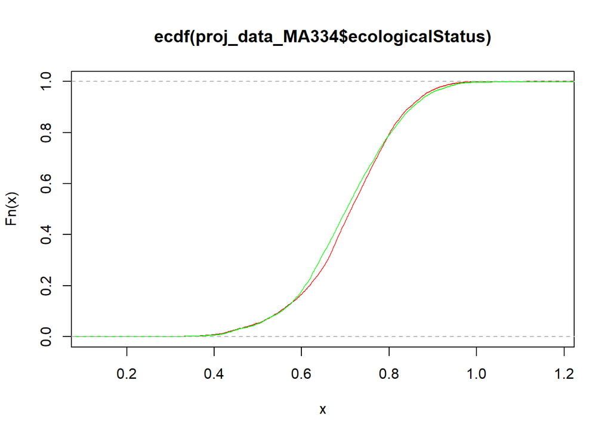

```
    Asymptotic two-sample Kolmogorov-Smirnov test

data:  proj_data_MA334$eco_status_7 and proj_data_MA334$ecologicalStatus
D = 0.056627, p-value = 3.199e-08
alternative hypothesis: two-sided
```

The study analyzes the *descriptive statistics* of every biodiversity indices by taking their mean, standard deviation and the skewness. This shows the values tend to change before and after the time period.

```
               taxi_group mean   sd skewness
1         Vascular_plants 0.78  0.1    -0.21
2              Bryophytes 0.79 0.13    -0.23
3             Butterflies 0.87 0.15    -0.47
4              Hoverflies 0.67 0.19    -0.52
5 Grasshoppers_._Crickets 0.62 0.21    -0.08
6                Carabids  0.6 0.22    -0.47
7                    Bees 0.59 0.31     0.97
```

### Linear Regression

Another simple linear regression between the 7 allocated taxonomic groups with the overall taxonomic groups and displaying the linReg values with different time periods. The regression line(red) and the identity line(green), which represents the perfect fit, has been overlaid on the scatter plot. Then using the qqnorm() on the residuals will give us information on the assumption of normality for the residuals. The intercept values demonstrates a positive association between the mean of all the taxonomic groups and the mean of the selected 7 taxonomic groups in both the periods y00 and y70.

```
Call:
lm(formula = proj_data_MA334$eco_status_7 ~ proj_data_MA334$ecologicalStatus)

Residuals:
      Min        1Q    Median        3Q       Max
-0.169597 -0.027686 -0.001266  0.024937  0.163067

Coefficients:
                                 Estimate Std. Error t value Pr(>|t|)
(Intercept)                      0.017305   0.003271    5.29 1.27e-07 ***
proj_data_MA334$ecologicalStatus 0.969322   0.004573  211.98  < 2e-16 ***
---
Signif. codes:  0 '***' 0.001 '**' 0.01 '*' 0.05 '.' 0.1 ' ' 1

Residual standard error: 0.03945 on 5596 degrees of freedom
Multiple R-squared:  0.8893,    Adjusted R-squared:  0.8892
F-statistic: 4.493e+04 on 1 and 5596 DF,  p-value: < 2.2e-16
```

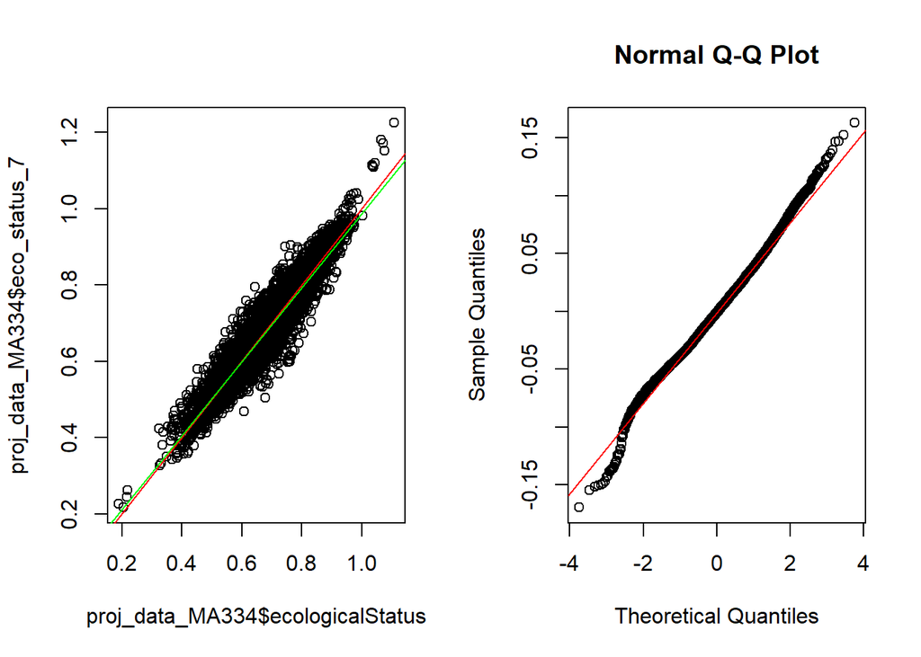

```
                         (Intercept) proj_data_MA334_Y70$ecologicalStatus
                          0.03404394                           0.94542215
```

```
                         (Intercept) proj_data_MA334_Y00$ecologicalStatus
                         0.002484931                          0.990926155
```

### Multiple Regression

```
Call:
lm(formula = eco_status_4 ~ ., data = trainingData[c(eco_selected_names,
    "eco_status_4")], na.action = na.omit, y = TRUE)

Residuals:
     Min       1Q   Median       3Q      Max
-0.34050 -0.05879  0.00344  0.05597  0.44489

Coefficients:
                         Estimate Std. Error t value Pr(>|t|)
(Intercept)              0.313704   0.014322  21.904   <2e-16 ***
Bees                     0.100281   0.005234  19.161   <2e-16 ***
Bryophytes              -0.223165   0.011325 -19.705   <2e-16 ***
Butterflies              0.182187   0.011627  15.669   <2e-16 ***
Carabids                 0.155607   0.008373  18.584   <2e-16 ***
Hoverflies               0.222926   0.009844  22.645   <2e-16 ***
Grasshoppers_._Crickets -0.015636   0.008179  -1.912    0.056 .
Vascular_plants          0.162559   0.015728  10.335   <2e-16 ***
---
Signif. codes:  0 '***' 0.001 '**' 0.01 '*' 0.05 '.' 0.1 ' ' 1

Residual standard error: 0.0922 on 4428 degrees of freedom
  (42 observations deleted due to missingness)
Multiple R-squared:  0.5501,    Adjusted R-squared:  0.5494
F-statistic: 773.6 on 7 and 4428 DF,  p-value: < 2.2e-16
```

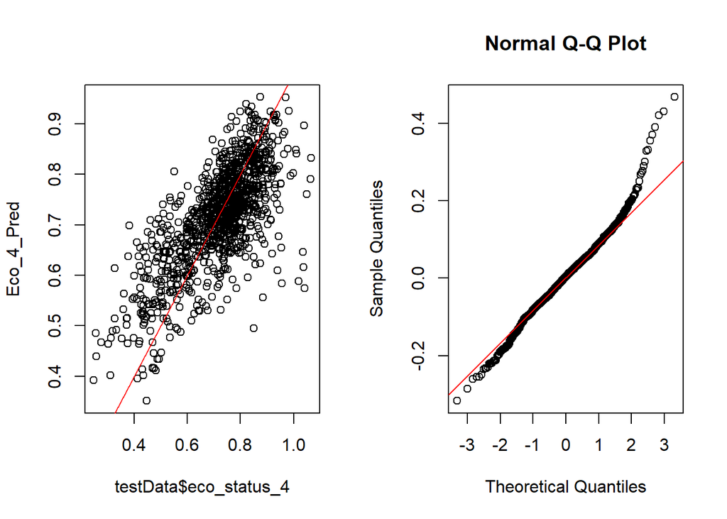